# 1.2. Multiple Linear Regression - Extended

### Example: Advertising Data

```python
# importing libraries
import pandas as pd
import numpy as np

import matplotlib.pyplot as plt
import seaborn as sns

# allow plots to appear directly in the notebook
%matplotlib inline
```

```python
# read data into a DataFrame
data = pd.read_csv('./Advertising.csv', index_col=0)
data.head()
```

|  | TV | Radio | Newspaper | Sales |
| --- | --- | --- | --- | --- |
| 1 | 276.12 | 45.36 | 83.04 | 26.52 |
| 2 | 53.40 | 47.16 | 54.12 | 12.48 |
| 3 | 20.64 | 55.08 | 83.16 | 11.16 |
| 4 | 181.80 | 49.56 | 70.20 | 22.20 |
| 5 | 216.96 | 12.96 | 70.08 | 15.48 |

```python
# print the shape of the DataFrame
data.shape
```

```
(200, 4)
```

```python
# number of null values
data.info()
```

```
<class 'pandas.core.frame.DataFrame'>
Int64Index: 200 entries, 1 to 200
Data columns (total 4 columns):
 #   Column     Non-Null Count  Dtype
---  ------     --------------  -----
 0   TV         200 non-null    float64
 1   Radio      200 non-null    float64
 2   Newspaper  200 non-null    float64
 3   Sales      200 non-null    float64
dtypes: float64(4)
memory usage: 7.8 KB
```

What are the **features** i.e., **X**?

- TV: advertising dollars spent on TV for a single product in a given market (in thousands of dollars)
- Radio: advertising dollars spent on Radio
- Newspaper: advertising dollars spent on Newspaper

What is the **response** i.e., **y**?

- Sales: sales of a single product in a given market (in thousands of widgets)

What else do we know?

- Because the response variable is continuous, this is a regression problem.
- Since we will be considering all the feature varibles in our model, this is a Multiple Linear Regression problem specifically.

Thus, in this case:

$$y = \beta_0 + \beta_1 * TV + \beta_2 * Radio + \beta_3 * Newspaper$$

There are 200 **observations**, and thus 200 markets in the dataset.

### Checking Linear Relationship

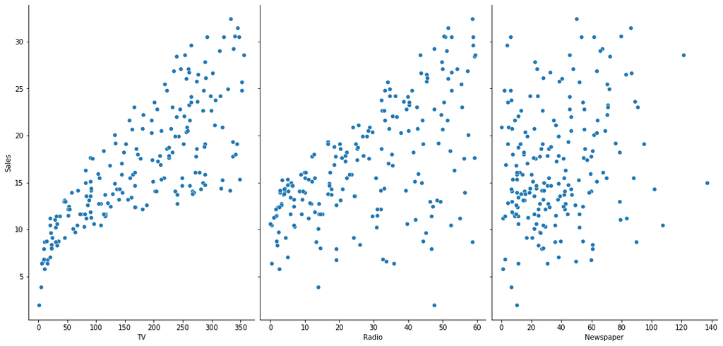

```python
# visualize the relationship between the features and the response using scatterplots
sns.pairplot(data, x_vars=['TV','Radio','Newspaper'], y_vars='Sales', height=7, aspect=0.7)  # aspect controls the size graphs

## plotting scatterplots with the line of best fit
# sns.pairplot(data, x_vars=['TV','Radio','Newspaper'], y_vars='Sales', height=7, aspect=0.7, kind='reg')
```

Conclusion:

- Strong relationship between TV ads and sales
- Weak relationship between Radio ads and sales
- Very weak relationship between Newspaper ads and sales

Let's estimate the model coefficients for the advertising data:

### Preparing X and y using pandas

**Remember:**

- scikit-learn expects X (feature matrix) and y (response vector) to be NumPy arrays
- However, pandas is built on top of NumPy
- Thus, X can be a pandas DataFrame (matrix) and y can be a pandas Series (vector)

```python
# declaring independent variable X & dependent vriable y

# create a Python list of feature names
feature_cols = ['TV', 'Radio', 'Newspaper']

# use the list to select a subset of the original DataFrame
X = data[feature_cols]

# equivalent command to do this in one line using double square brackets i.e., X = data[['TV', 'Radio', 'Newspaper']]
# inner bracket is a list
# outer bracker accesses a subset of the original DataFrame


# select target variable from the DataFrame
y = data['Sales']
```

```python
# check the shape of X and y
print(X.shape)
print(y.shape)
```

```
(200, 3)
(200,)
```

### Splitting X and y into training and testing sets

```python
# importing module for splitting the data

from sklearn.model_selection import train_test_split

X_train, X_test, y_train, y_test = train_test_split(X, y, random_state = 1) #unpacking, default splitting ratio is 75:25
```

```python
# default split is 75% for training and 25% for testing
print(X_train.shape)
print(X_test.shape)
print(y_train.shape)
print(y_test.shape)
```

```
(150, 3)
(50, 3)
(150,)
(50,)
```

### Fitting MLR model on training dataset

```python
# import model
from sklearn.linear_model import LinearRegression

# instantiate
linreg = LinearRegression()

# fit the model to the training data (learn the coefficients)
linreg.fit(X_train, y_train)
```

```
LinearRegression(copy_X=True, fit_intercept=True, n_jobs=None, normalize=False)
```

### Get Coefficients

```python
# print the intercept and coefficients
print(linreg.intercept_)
print(linreg.coef_)
```

```
3.4523599467815167
[0.04656457 0.17915812 0.00345046]
```

```python
# pair the feature names with the coefficients

for i,j in zip(feature_cols, linreg.coef_):
    print (i,':',round(j,3))
```

```
TV : 0.047
Radio : 0.179
Newspaper : 0.003
```

How do we interpret these coefficients?

### Make predictions on test dataset

```python
# make predictions on the testing set
y_pred = linreg.predict(X_test)
```

```python
# import module to be used for model evaluation

from sklearn import metrics
```

```python
# Mean Absolute Error (MAE)
print("Mean absolute error (MAE):", metrics.mean_absolute_error(y_test,y_pred))
```

```
Mean absolute error (MAE): 1.2802700499114252
```

```python
# Mean Squared Error
print("Mean square error (MSE):", metrics.mean_squared_error(y_test,y_pred))
```

```
Mean square error (MSE): 2.8411856931288044
```

```python
# Root Mean Squared Error
print("Root mean square error (RMSE):", np.sqrt(metrics.mean_squared_error(y_test,y_pred)))
```

```
Root mean square error (RMSE): 1.6855817076394737
```

### R^2 (R-squared)

```python
# R2

print("R-squared value of predictions:",metrics.r2_score(y_test,y_pred))
```

```
R-squared value of predictions: 0.9156213613792233
```

This model has a higher **R-squared** (0.915) than the SLR model we previously used, which means that this model provides a better fit to the data than a model that only one variable.

```python
#cross-checking

df_check = pd.DataFrame({'Actual': y_test[:10].values, 'Predicted': y_pred[:10].ravel()})
df_check
```

|  | Actual | Predicted |
| --- | --- | --- |
| 0 | 28.56 | 26.050924 |
| 1 | 19.92 | 19.692663 |
| 2 | 11.40 | 9.131461 |
| 3 | 17.76 | 21.369235 |
| 4 | 21.12 | 22.337563 |
| 5 | 30.60 | 28.602888 |
| 6 | 20.28 | 19.589864 |
| 7 | 15.48 | 16.118706 |
| 8 | 12.60 | 11.006081 |
| 9 | 20.52 | 20.800624 |

## Feature Selection

How do I decide **which features to include** in a linear model? which one or which two are important? Are all of them important?

To find this out, we will perform Feature Selection or variable selection. Now one way of doing this is trying all possible combinations of independent variables. Another idea is strategically create a model by checking whether the R-squared as you add new features.

This idea is called **Forward Selection** and the steps to follow are:

1) We start with a model without any predictor and just the intercept term.

2) We then perform simple linear regression for each predictor to find the best performer (greatest $R^2$).

3) We then add another variable to it and check for the best 2-variable combination again by checking greatest $R^2$.

4) After that the best 3-variable combination is checked, and so on. The approach is stopped when some stopping rule is satisfied.

**Let’s first evaluate models with single predictors one by one, starting with TV.**

```python
#For TV

# create a Python list of feature names
feature_cols = ['TV']

# use the list to select a subset of the original DataFrame
X = data[feature_cols]

# select target variable from the DataFrame
y = data['Sales']

# splitting the data into train-test
X_train, X_test, y_train, y_test = train_test_split(X, y, random_state = 1)

# instantiate
model_TV = LinearRegression()

# fit the model to the training data (learn the coefficients)
model_TV.fit(X_train, y_train)

# make predictions on the testing set
y_pred = model_TV.predict(X_test)

#R2
R2_TV = round(metrics.r2_score(y_test,y_pred),2)
print("R-squared value:",R2_TV)
```

```
R-squared value: 0.56
```

```python
#For Radio

# create a Python list of feature names
feature_cols = ['Radio']

# use the list to select a subset of the original DataFrame
X = data[feature_cols]

# select target variable from the DataFrame
y = data['Sales']

# splitting the data into train-test
X_train, X_test, y_train, y_test = train_test_split(X, y, random_state = 1)

# instantiate
model_Radio = LinearRegression()

# fit the model to the training data (learn the coefficients)
model_Radio.fit(X_train, y_train)

# make predictions on the testing set
y_pred = model_Radio.predict(X_test)

#R2
R2_Radio = round(metrics.r2_score(y_test,y_pred),2)
print("R-squared value:",R2_Radio)
```

```
R-squared value: 0.41
```

```python
#For Newspaper

# create a Python list of feature names
feature_cols = ['Newspaper']

# use the list to select a subset of the original DataFrame
X = data[feature_cols]

# select target variable from the DataFrame
y = data['Sales']

# splitting the data into train-test
X_train, X_test, y_train, y_test = train_test_split(X, y, random_state = 1)

# instantiate
model_NP = LinearRegression()

# fit the model to the training data (learn the coefficients)
model_NP.fit(X_train, y_train)

# make predictions on the testing set
y_pred = model_NP.predict(X_test)

#R2
R2_NP = round(metrics.r2_score(y_test,y_pred),2)
print("R-squared value:",R2_NP)
```

```
R-squared value: -0.08
```

We observe that for model_TV, R² value is the most among all the models. Hence we select model_TV as our base model to move forward.

Now, we will add the radio and newspaper one by one and check the new values.

```python
#For TV, Radio

# create a Python list of feature names
feature_cols = ['TV','Radio']

# use the list to select a subset of the original DataFrame
X = data[feature_cols]

# select target variable from the DataFrame
y = data['Sales']

# splitting the data into train-test
X_train, X_test, y_train, y_test = train_test_split(X, y, random_state = 1)

# instantiate
model_TV_Radio = LinearRegression()

# fit the model to the training data (learn the coefficients)
model_TV_Radio.fit(X_train, y_train)

# make predictions on the testing set
y_pred = model_TV_Radio.predict(X_test)

# R2
R2_TV_Radio = round(metrics.r2_score(y_test,y_pred),2)
print("R-squared value:",R2_TV_Radio)
```

```
R-squared value: 0.92
```

```python
#For TV, Newspaper

# create a Python list of feature names
feature_cols = ['TV','Newspaper']

# use the list to select a subset of the original DataFrame
X = data[feature_cols]

# select target variable from the DataFrame
y = data['Sales']

# splitting the data into train-test
X_train, X_test, y_train, y_test = train_test_split(X, y, random_state = 1)

# instantiate
model_TV_NP = LinearRegression()

# fit the model to the training data (learn the coefficients)
model_TV_NP.fit(X_train, y_train)

# make predictions on the testing set
y_pred = model_TV_NP.predict(X_test)

#R2
R2_TV_NP = round(metrics.r2_score(y_test,y_pred),2)
print("R-squared value:",R2_TV_NP)
```

```
R-squared value: 0.52
```

```python
#For TV, Radio, Newspaper

# create a Python list of feature names
feature_cols = ['TV','Radio','Newspaper']

# use the list to select a subset of the original DataFrame
X = data[feature_cols]

# select target variable from the DataFrame
y = data['Sales']

# splitting the data into train-test
X_train, X_test, y_train, y_test = train_test_split(X, y, random_state = 1)

# instantiate
model_TV_Radio_NP = LinearRegression()

# fit the model to the training data (learn the coefficients)
model_TV_Radio_NP.fit(X_train, y_train)

# make predictions on the testing set
y_pred = model_TV_Radio_NP.predict(X_test)

#R2
R2_TV_Radio_NP = round(metrics.r2_score(y_test,y_pred),2)
print("R-squared value:",R2_TV_Radio_NP)
```

```
R-squared value: 0.92
```

The values have not improved with any significance. Hence, it’s imperative to not add newspaper and finalize the model with TV and radio as selected features.

### Adjusted - $R^2$

**R-squared will generally always increase as you add more features to the model, even if they are unrelated to the response (target variable)**. Thus, selecting the model with the highest R-squared is not a reliable approach for choosing the best linear model.

One attempt to adjust for this phenomenon and penalize additional complexity (to control for overfitting) is Adjusted $R^2$. Adjusted-$R^2$ reduces $R^2$ as more parameters are added to the model. There is a simple relationship between adjusted and regular $R^2$:

$$Adjusted\ R^2=1-(1-R^2)\frac{n-1}{n-p-1}$$

where:

$n$ = total no. of observations

$p$ = number of feature variables

In simple, $R^2$ shows how well terms (data points) fit a curve or line. Adjusted $R^2$ also indicates how well terms fit a curve or line, but adjusts for the number of terms in a model. **If you add more and more useless variables to a model, adjusted $R^2$ will decrease**. If you add more useful variables, adjusted $R^2$ will increase. *Adjusted R2 will always be less than or equal to R2*.

Adjusted $R^2$ is much better than regular $R^2$ and due to this fact, it should always be used in place of regular $R^2$.

```python
# Adjusted R2 for Sales ~ TV + Radio

print("R-squared value:", R2_TV_Radio)

n = 50
p = 2

Adj_R2_TV_Radio = 1 - ((1 - R2_TV_Radio)*(n-1)/(n-p-1))
print("Adjusted R-squared value:",Adj_R2_TV_Radio)
```

```
R-squared value: 0.92
Adjusted R-squared value: 0.9165957446808511
```

```python
# Adjusted R2 Sales ~ TV + Newspaper

print("R-squared value:", R2_TV_NP)

n = 50
p = 2

Adj_R2_TV_NP = 1 - ((1 - R2_TV_NP)*(n-1)/(n-p-1))
print("Adjusted R-squared value:",Adj_R2_TV_NP)
```

```
R-squared value: 0.52
Adjusted R-squared value: 0.4995744680851064
```

```python
# Adjusted R2 Sales ~ TV + Radio + Newspaper

print("R-squared value:", R2_TV_Radio_NP)

n = 50  # number of observations
p = 3   # number of independent varibales

Adj_R2_TV_Radio_NP = 1 - ((1 - R2_TV_Radio_NP)*(n-1)/(n-p-1))
print("Adjusted R-squared value:",Adj_R2_TV_Radio_NP)
```

```
R-squared value: 0.92
Adjusted R-squared value: 0.9147826086956522
```

## Handling Categorical Features with Two Categories

Up to now, all of our features have been numeric. What if one of our features was categorical?

Let's create a new feature called **Size**, and randomly assign observations to be **small or large**:

```python
# set a seed for reproducibility
np.random.seed(12345)

# create a Series of booleans in which roughly half are True
nums = np.random.rand(len(data))
mask_large = nums > 0.5

# initially set Size to small, then change roughly half to be large
data['Size'] = 'small'
data.loc[mask_large, 'Size'] = 'large'
data.head()
```

|  | TV | Radio | Newspaper | Sales | Size |
| --- | --- | --- | --- | --- | --- |
| 1 | 276.12 | 45.36 | 83.04 | 26.52 | large |
| 2 | 53.40 | 47.16 | 54.12 | 12.48 | small |
| 3 | 20.64 | 55.08 | 83.16 | 11.16 | small |
| 4 | 181.80 | 49.56 | 70.20 | 22.20 | small |
| 5 | 216.96 | 12.96 | 70.08 | 15.48 | large |

```python
from sklearn.preprocessing import LabelEncoder

le = LabelEncoder()

size_labels = le.fit_transform(data['Size'])

data['Size'] = size_labels
```

```python
data.head()
```

|  | TV | Radio | Newspaper | Sales | Size |
| --- | --- | --- | --- | --- | --- |
| 1 | 276.12 | 45.36 | 83.04 | 26.52 | 0 |
| 2 | 53.40 | 47.16 | 54.12 | 12.48 | 1 |
| 3 | 20.64 | 55.08 | 83.16 | 11.16 | 1 |
| 4 | 181.80 | 49.56 | 70.20 | 22.20 | 1 |
| 5 | 216.96 | 12.96 | 70.08 | 15.48 | 0 |

Let's redo the multiple linear regression and include the **Size_small** feature:

```python
# create X and y
feature_cols = ['TV', 'Radio', 'Newspaper', 'Size']
X = data[feature_cols]
y = data.Sales

# instantiate, fit
lm2 = LinearRegression()
lm2.fit(X, y)

# pair the feature names with the coefficients

for i,j in zip(feature_cols, lm2.coef_):
    print (i,':',round(j,3))
```

```
TV : 0.046
Radio : 0.189
Newspaper : -0.001
Size : -0.069
```

What if we had reversed the 0/1 coding and created the feature 'Size_large' instead? The coefficient would be the same, except it would be **positive instead of negative**. As such, your choice of category for the baseline does not matter, all that changes is your **interpretation** of the coefficient.

## Handling Categorical Features with More than Two Categories

Let's create a new feature called **Area**, and randomly assign observations to be **rural, suburban, or urban**:

```python
# set a seed for reproducibility
np.random.seed(123456)

# assign roughly one third of observations to each group
nums = np.random.rand(len(data))
mask_suburban = (nums > 0.33) & (nums < 0.66)
mask_urban = nums > 0.66
data['Area'] = 'rural'
data.loc[mask_suburban, 'Area'] = 'suburban'
data.loc[mask_urban, 'Area'] = 'urban'
data.head()
```

|  | TV | Radio | Newspaper | Sales | Size | Area |
| --- | --- | --- | --- | --- | --- | --- |
| 1 | 276.12 | 45.36 | 83.04 | 26.52 | 0 | rural |
| 2 | 53.40 | 47.16 | 54.12 | 12.48 | 1 | urban |
| 3 | 20.64 | 55.08 | 83.16 | 11.16 | 1 | rural |
| 4 | 181.80 | 49.56 | 70.20 | 22.20 | 1 | urban |
| 5 | 216.96 | 12.96 | 70.08 | 15.48 | 0 | suburban |

We have to represent Area numerically, but we can't simply code it as `0 = rural`, `1 = suburban`, `2 = urban` because that would imply an **ordered relationship** between suburban and urban, and thus urban is somehow "twice" the suburban category. Note that if you do have ordered categories (i.e., strongly disagree, disagree, neutral, agree, strongly agree), you can use a single dummy variable and represent the categories numerically (such as 1, 2, 3, 4, 5).

Anyway, our Area feature is unordered, so we have to create **additional dummy variables**.

## One Hot Encoding

One hot encoding enables us to create new attributes according to the number of classes present in the categorical attribute i.e if there are $n$ number of categories in categorical attribute, $n$ new attributes will be created. These attributes created are called **Dummy Variables**. Hence, dummy variables are “proxy” variables for categorical data in regression models.

```python
from sklearn.preprocessing import OneHotEncoder

area_ohe = OneHotEncoder()   #create an instance of OHE
area_feature_arr = area_ohe.fit_transform(data[['Area']]).toarray()

#coverting OHE array to dataframe
area_features_df = pd.DataFrame(area_feature_arr,columns = area_ohe.get_feature_names())
```

```python
## another way of creating dataframe
# area_feature_labels = ['Area_rural','Area_urban','Area_suburban']
# area_features_df = pd.DataFrame(area_feature_arr,columns = area_feature_labels)
```

```python
area_features_df
```

|  | x0_rural | x0_suburban | x0_urban |
| --- | --- | --- | --- |
| 0 | 1.0 | 0.0 | 0.0 |
| 1 | 0.0 | 0.0 | 1.0 |
| 2 | 1.0 | 0.0 | 0.0 |
| 3 | 0.0 | 0.0 | 1.0 |
| 4 | 0.0 | 1.0 | 0.0 |
| ... | ... | ... | ... |
| 195 | 0.0 | 1.0 | 0.0 |
| 196 | 0.0 | 0.0 | 1.0 |
| 197 | 0.0 | 1.0 | 0.0 |
| 198 | 1.0 | 0.0 | 0.0 |
| 199 | 1.0 | 0.0 | 0.0 |

200 rows × 3 columns

```python
data
```

|  | TV | Radio | Newspaper | Sales | Size | Area |
| --- | --- | --- | --- | --- | --- | --- |
| 1 | 276.12 | 45.36 | 83.04 | 26.52 | 0 | rural |
| 2 | 53.40 | 47.16 | 54.12 | 12.48 | 1 | urban |
| 3 | 20.64 | 55.08 | 83.16 | 11.16 | 1 | rural |
| 4 | 181.80 | 49.56 | 70.20 | 22.20 | 1 | urban |
| 5 | 216.96 | 12.96 | 70.08 | 15.48 | 0 | suburban |
| ... | ... | ... | ... | ... | ... | ... |
| 196 | 45.84 | 4.44 | 16.56 | 9.12 | 1 | suburban |
| 197 | 113.04 | 5.88 | 9.72 | 11.64 | 1 | urban |
| 198 | 212.40 | 11.16 | 7.68 | 15.36 | 1 | suburban |
| 199 | 340.32 | 50.40 | 79.44 | 30.60 | 1 | rural |
| 200 | 278.52 | 10.32 | 10.44 | 16.08 | 0 | rural |

200 rows × 6 columns

Now the next part is to concatenate feature data frame with our dataset. But observe that, the indices of both the data frames are different, hence we first reset the indices for `data`

```python
data.reset_index(inplace=True,drop=True)   #resetting indices before concatination
data
```

|  | TV | Radio | Newspaper | Sales | Size | Area |
| --- | --- | --- | --- | --- | --- | --- |
| 0 | 276.12 | 45.36 | 83.04 | 26.52 | 0 | rural |
| 1 | 53.40 | 47.16 | 54.12 | 12.48 | 1 | urban |
| 2 | 20.64 | 55.08 | 83.16 | 11.16 | 1 | rural |
| 3 | 181.80 | 49.56 | 70.20 | 22.20 | 1 | urban |
| 4 | 216.96 | 12.96 | 70.08 | 15.48 | 0 | suburban |
| ... | ... | ... | ... | ... | ... | ... |
| 195 | 45.84 | 4.44 | 16.56 | 9.12 | 1 | suburban |
| 196 | 113.04 | 5.88 | 9.72 | 11.64 | 1 | urban |
| 197 | 212.40 | 11.16 | 7.68 | 15.36 | 1 | suburban |
| 198 | 340.32 | 50.40 | 79.44 | 30.60 | 1 | rural |
| 199 | 278.52 | 10.32 | 10.44 | 16.08 | 0 | rural |

200 rows × 6 columns

```python
data.drop(columns=['Area'])  #droping `Area` column as it's now one hot encoded
```

|  | TV | Radio | Newspaper | Sales | Size |
| --- | --- | --- | --- | --- | --- |
| 0 | 276.12 | 45.36 | 83.04 | 26.52 | 0 |
| 1 | 53.40 | 47.16 | 54.12 | 12.48 | 1 |
| 2 | 20.64 | 55.08 | 83.16 | 11.16 | 1 |
| 3 | 181.80 | 49.56 | 70.20 | 22.20 | 1 |
| 4 | 216.96 | 12.96 | 70.08 | 15.48 | 0 |
| ... | ... | ... | ... | ... | ... |
| 195 | 45.84 | 4.44 | 16.56 | 9.12 | 1 |
| 196 | 113.04 | 5.88 | 9.72 | 11.64 | 1 |
| 197 | 212.40 | 11.16 | 7.68 | 15.36 | 1 |
| 198 | 340.32 | 50.40 | 79.44 | 30.60 | 1 |
| 199 | 278.52 | 10.32 | 10.44 | 16.08 | 0 |

200 rows × 5 columns

```python
#concat with original data
data_new = pd.concat([data, area_features_df], axis=1)
```

```python
data_new.head()
```

|  | TV | Radio | Newspaper | Sales | Size | Area | x0_rural | x0_suburban | x0_urban |
| --- | --- | --- | --- | --- | --- | --- | --- | --- | --- |
| 0 | 276.12 | 45.36 | 83.04 | 26.52 | 0 | rural | 1.0 | 0.0 | 0.0 |
| 1 | 53.40 | 47.16 | 54.12 | 12.48 | 1 | urban | 0.0 | 0.0 | 1.0 |
| 2 | 20.64 | 55.08 | 83.16 | 11.16 | 1 | rural | 1.0 | 0.0 | 0.0 |
| 3 | 181.80 | 49.56 | 70.20 | 22.20 | 1 | urban | 0.0 | 0.0 | 1.0 |
| 4 | 216.96 | 12.96 | 70.08 | 15.48 | 0 | suburban | 0.0 | 1.0 | 0.0 |

```python
#################
# Alternate way
#################

# from sklearn.compose import ColumnTransformer
# from sklearn.preprocessing import OneHotEncoder

# ct = ColumnTransformer(transformers=[('encoder', OneHotEncoder(), [-1])], remainder='passthrough')
# data2 = np.array(ct.fit_transform(data), dtype = np.str)

# cols = ['Area_rural','Area_urban','Area_suburban'] + list(data.columns)[:-1]
# ## cols

# data3 = pd.DataFrame(data2, columns = cols)
# # data3
```

### Dummy Variable Trap

The Dummy variable trap is a scenario where there are attributes which are highly correlated (Multicollinear) and one variable predicts the value of others. When we use one hot encoding for handling the categorical data, then one dummy variable (attribute) can be predicted with the help of other dummy variables. Hence, one dummy variable is highly correlated with other dummy variables. Using all dummy variables for regression models lead to dummy variable trap. So, the regression models should be designed excluding one dummy variable.

Though we are getting rid of categorical variables by using dummy variables, we are introducing multicollinearity in the data. This is the TRAP!!!!!!!-----

The TRAP:

Do you see a problem with above training data? If no, please have a look at below equation:

*Area_rural + Area_suburban + Area_urban = 1*

Above equation hold true for all the data points in the training data. If we break the problem further,

- Area_rural can be predicted by Area_suburban and Area_urban
- Area_suburban can be predicted by Area_rural and Area_urban
- Area_urban can be predicted by Area_rural and Area_suburban

If 2 values are known, third one can be predicted!!!!!

This is a clear case of perfect multicollinearity.

Recall that, multicollinearity is a phenomenon in which one independent variable in a multiple regression model can be linearly predicted from the others with a substantial degree of accuracy.

Escape from the TRAP:

To avoid the TRAP, the solution is to declare one variable less that number of levels in the categorical variable

**Dummy variables count = Category count — 1**

In our case, category count = 3 (i.e, rural,suburban, urban)

Hence, to avoid TRAP, we should have 3–1 = 2 dummy variables created.

The obvious question is **how to decide which variable to drop?** The answer is any.

```python
data_new.drop(columns = ['x0_rural'],inplace=True)
data_new.head()
```

|  | TV | Radio | Newspaper | Sales | Size | Area | x0_suburban | x0_urban |
| --- | --- | --- | --- | --- | --- | --- | --- | --- |
| 0 | 276.12 | 45.36 | 83.04 | 26.52 | 0 | rural | 0.0 | 0.0 |
| 1 | 53.40 | 47.16 | 54.12 | 12.48 | 1 | urban | 0.0 | 1.0 |
| 2 | 20.64 | 55.08 | 83.16 | 11.16 | 1 | rural | 0.0 | 0.0 |
| 3 | 181.80 | 49.56 | 70.20 | 22.20 | 1 | urban | 0.0 | 1.0 |
| 4 | 216.96 | 12.96 | 70.08 | 15.48 | 0 | suburban | 1.0 | 0.0 |

```python
# create X and y
feature_cols = ['TV', 'Radio', 'Newspaper', 'Size','x0_suburban','x0_urban']
X = data_new[feature_cols]
y = data_new.Sales

# instantiate, fit
lm3 = LinearRegression()
lm3.fit(X, y)

# pair the feature names with the coefficients

for i,j in zip(feature_cols, lm3.coef_):
    print (i,':',round(j,3))
```

```
TV : 0.046
Radio : 0.188
Newspaper : -0.001
Size : -0.093
x0_suburban : -0.128
x0_urban : 0.322
```

However, **how will you interpret a categorical independent variable?** It may not be right to interpret it as when one unit change in `rural` !!

The correct approach in this case is to interpret the coefficient with respect to the **baseline dummy** or the dummy that *we did not add in the model*.

Going back to the example, we dropped `rural` from the model. Hence, it acts a baseline dummy and does not provide any incremental information to the model.

A positive `urban` coefficient means that as compared to `rural`, sales is more associated with `urban`. A negative `suburban` coefficient will indicate that sales is less associated to `suburban` as compared to `rural`.

### Additional Reading:

Let's explore how to handle categorical features using **using pandas only**:

```python
# read data into a DataFrame
data = pd.read_csv('./Advertising.csv', index_col=0)
data.head()
```

|  | TV | Radio | Newspaper | Sales |
| --- | --- | --- | --- | --- |
| 1 | 276.12 | 45.36 | 83.04 | 26.52 |
| 2 | 53.40 | 47.16 | 54.12 | 12.48 |
| 3 | 20.64 | 55.08 | 83.16 | 11.16 |
| 4 | 181.80 | 49.56 | 70.20 | 22.20 |
| 5 | 216.96 | 12.96 | 70.08 | 15.48 |

**Handling Categorical Features with Two Categories**

```python
# set a seed for reproducibility
np.random.seed(12345)

# create a Series of booleans in which roughly half are True
nums = np.random.rand(len(data))
mask_large = nums > 0.5

# initially set Size to small, then change roughly half to be large
data['Size'] = 'small'
data.loc[mask_large, 'Size'] = 'large'
data.head()
```

|  | TV | Radio | Newspaper | Sales | Size |
| --- | --- | --- | --- | --- | --- |
| 1 | 276.12 | 45.36 | 83.04 | 26.52 | large |
| 2 | 53.40 | 47.16 | 54.12 | 12.48 | small |
| 3 | 20.64 | 55.08 | 83.16 | 11.16 | small |
| 4 | 181.80 | 49.56 | 70.20 | 22.20 | small |
| 5 | 216.96 | 12.96 | 70.08 | 15.48 | large |

```python
# create a new Series called Size_large
data['Size_large'] = data.Size.map({'small':0, 'large':1})
data.head()
```

|  | TV | Radio | Newspaper | Sales | Size | Size_large |
| --- | --- | --- | --- | --- | --- | --- |
| 1 | 276.12 | 45.36 | 83.04 | 26.52 | large | 1 |
| 2 | 53.40 | 47.16 | 54.12 | 12.48 | small | 0 |
| 3 | 20.64 | 55.08 | 83.16 | 11.16 | small | 0 |
| 4 | 181.80 | 49.56 | 70.20 | 22.20 | small | 0 |
| 5 | 216.96 | 12.96 | 70.08 | 15.48 | large | 1 |

**Handling Categorical Features with More than Two Categories**

```python
# set a seed for reproducibility
np.random.seed(123456)

# assign roughly one third of observations to each group
nums = np.random.rand(len(data))
mask_suburban = (nums > 0.33) & (nums < 0.66)
mask_urban = nums > 0.66
data['Area'] = 'rural'
data.loc[mask_suburban, 'Area'] = 'suburban'
data.loc[mask_urban, 'Area'] = 'urban'
data.head()
```

|  | TV | Radio | Newspaper | Sales | Size | Size_large | Area |
| --- | --- | --- | --- | --- | --- | --- | --- |
| 1 | 276.12 | 45.36 | 83.04 | 26.52 | large | 1 | rural |
| 2 | 53.40 | 47.16 | 54.12 | 12.48 | small | 0 | urban |
| 3 | 20.64 | 55.08 | 83.16 | 11.16 | small | 0 | rural |
| 4 | 181.80 | 49.56 | 70.20 | 22.20 | small | 0 | urban |
| 5 | 216.96 | 12.96 | 70.08 | 15.48 | large | 1 | suburban |

```python
# create three dummy variables using get_dummies
pd.get_dummies(data.Area, prefix='Area').head()
```

|  | Area_rural | Area_suburban | Area_urban |
| --- | --- | --- | --- |
| 1 | 1 | 0 | 0 |
| 2 | 0 | 0 | 1 |
| 3 | 1 | 0 | 0 |
| 4 | 0 | 0 | 1 |
| 5 | 0 | 1 | 0 |

```python
# create three dummy variables using get_dummies, then exclude the first dummy column
area_dummies = pd.get_dummies(data.Area, prefix='Area').iloc[:, 1:]
area_dummies.head()
```

|  | Area_suburban | Area_urban |
| --- | --- | --- |
| 1 | 0 | 0 |
| 2 | 0 | 1 |
| 3 | 0 | 0 |
| 4 | 0 | 1 |
| 5 | 1 | 0 |

```python
# concatenate the dummy variable columns onto the DataFrame (axis=0 means rows, axis=1 means columns)
data = pd.concat([data, area_dummies], axis=1)
data.head()
```

|  | TV | Radio | Newspaper | Sales | Size | Size_large | Area | Area_suburban | Area_urban |
| --- | --- | --- | --- | --- | --- | --- | --- | --- | --- |
| 1 | 276.12 | 45.36 | 83.04 | 26.52 | large | 1 | rural | 0 | 0 |
| 2 | 53.40 | 47.16 | 54.12 | 12.48 | small | 0 | urban | 0 | 1 |
| 3 | 20.64 | 55.08 | 83.16 | 11.16 | small | 0 | rural | 0 | 0 |
| 4 | 181.80 | 49.56 | 70.20 | 22.20 | small | 0 | urban | 0 | 1 |
| 5 | 216.96 | 12.96 | 70.08 | 15.48 | large | 1 | suburban | 1 | 0 |